# Assignment 2

Sebastian Batchford

2026-10-25

## Loading the packages we need

```r
# Part 1
install.packages("dslabs")
library("dslabs")

# Install pacman first (only once):
install.packages("pacman")
```

```r
# Load and install packages:
pacman::p_load(ggplot2, dplyr, tidyr) #So it installs the library if needed + imports it in one step.

# Part 2
install.packages("car")
library("car")
```

# Part 1:

Use the ‘divorce_margarine’ dataset from the ‘dslabs’ package to explore the relationship between margarine consumption and divorce rates in Maine. Visualise the data, make a correlation test. Report the correlation coefficient and p-value in APA format, and briefly discuss the results in a practical way

### Loading and looking at the ‘divorce_margarine’ dataset

```r
df_divorce_marg <- as.data.frame(divorce_margarine)
head(df_divorce_marg)
```

```
##   divorce_rate_maine margarine_consumption_per_capita year
## 1                5.0                              8.2 2000
## 2                4.7                              7.0 2001
## 3                4.6                              6.5 2002
## 4                4.4                              5.3 2003
## 5                4.3                              5.2 2004
## 6                4.1                              4.0 2005
```

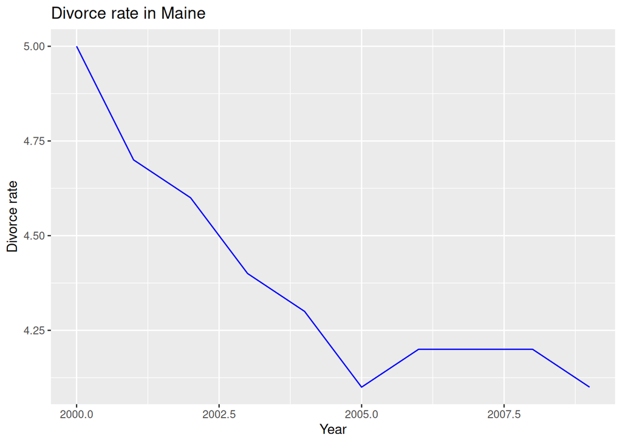

```r
# Looking at divorce rate over time
ggplot(df_divorce_marg,aes(x=year, y=divorce_rate_maine)) +
  geom_line(color = "blue") +
  labs(title = "Divorce rate in Maine", x = "Year", y = "Divorce rate")
```

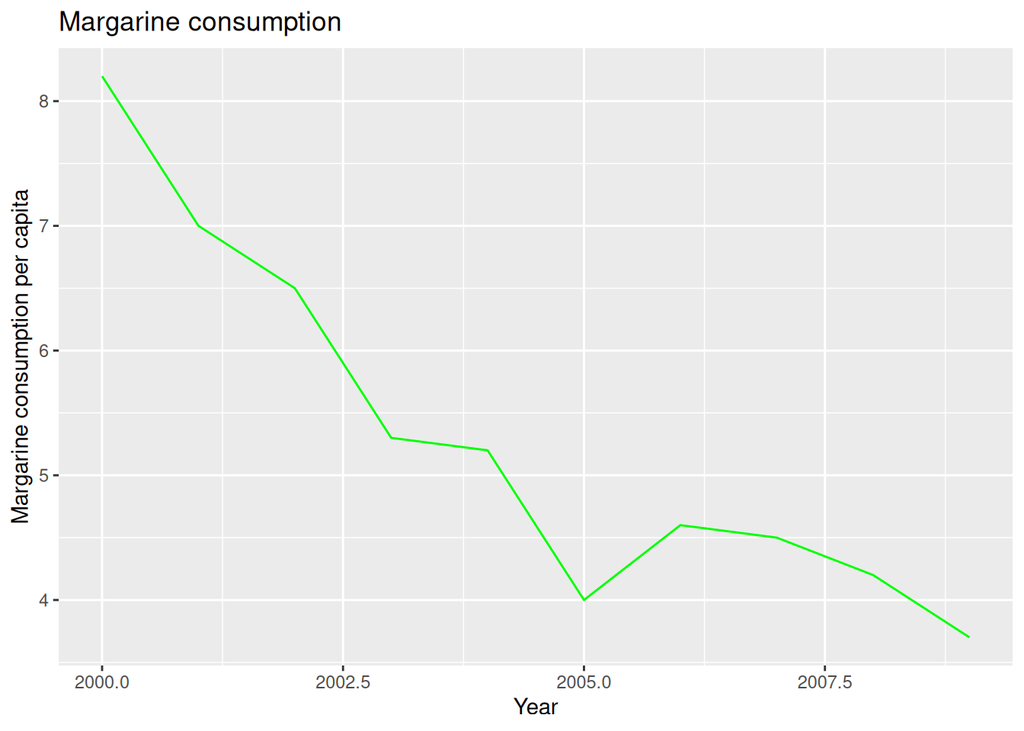

```r
# Looking at margarine consumption over time
ggplot(df_divorce_marg,aes(x=year, y=margarine_consumption_per_capita)) +
  geom_line(color = "green") +
  labs(title = "Margarine consumption", x = "Year", y = "Margarine consumption per capita")
```

They looked like they may correlate…

### Histograms

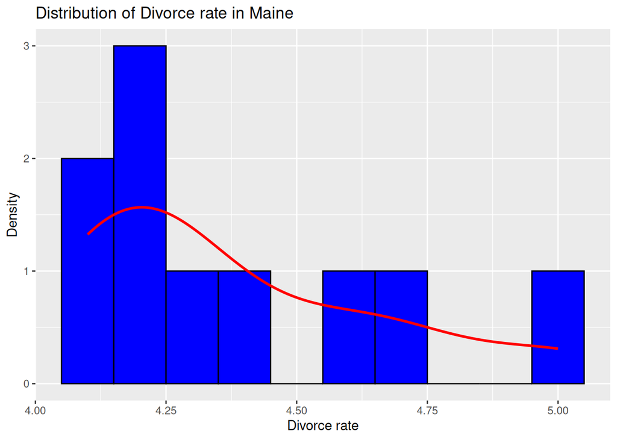

```r
ggplot(df_divorce_marg, aes(x=divorce_rate_maine)) +
  geom_histogram(aes(y = after_stat(density)), bins = 10, fill = "blue", color = "black") +
  geom_density(color = "red", size = 1) +
  labs(title = "Distribution of Divorce rate in Maine", x = "Divorce rate", y = "Density")
```

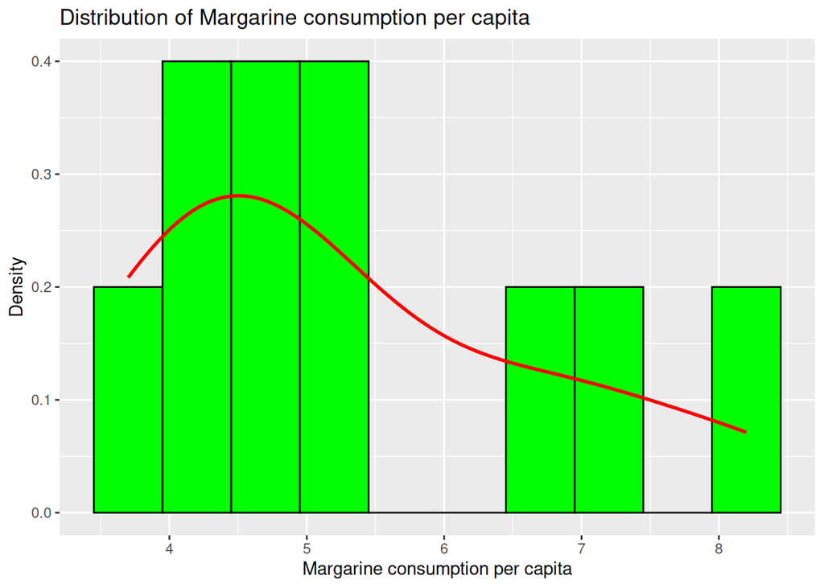

```r
ggplot(df_divorce_marg, aes(x=margarine_consumption_per_capita)) +
  geom_histogram(aes(y = after_stat(density)), bins = 10, fill = "green", color = "black") +
  geom_density(color = "red", size = 1) +
  labs(title = "Distribution of Margarine consumption per capita", x = "Margarine consumption per capita", y = "Density")
```

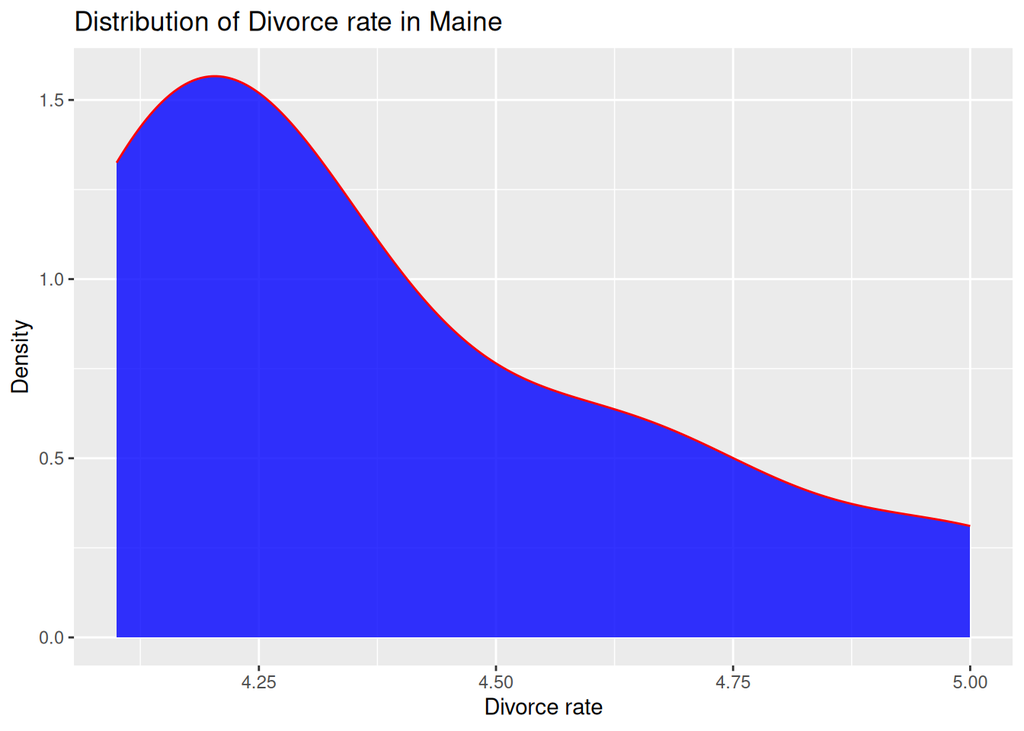

```r
ggplot(df_divorce_marg, aes(x=divorce_rate_maine)) +
  geom_density(fill="blue", color = "red", alpha = 0.8) +
  labs(title = "Distribution of Divorce rate in Maine", x = "Divorce rate", y = "Density")
```

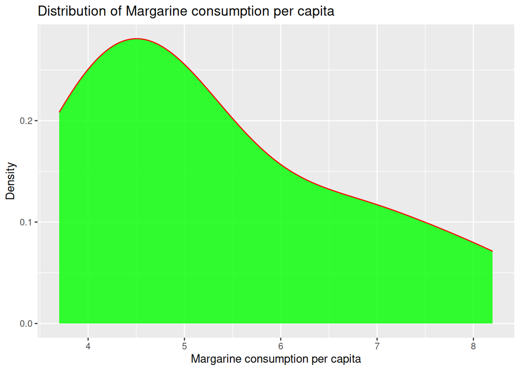

```r
ggplot(df_divorce_marg, aes(x=margarine_consumption_per_capita)) +
  geom_density(fill="green", color = "red", alpha = 0.8) +
  labs(title = "Distribution of Margarine consumption per capita", x = "Margarine consumption per capita", y = "Density")
```

None of the variables seem to have a normal distribution.

### QQ-plots

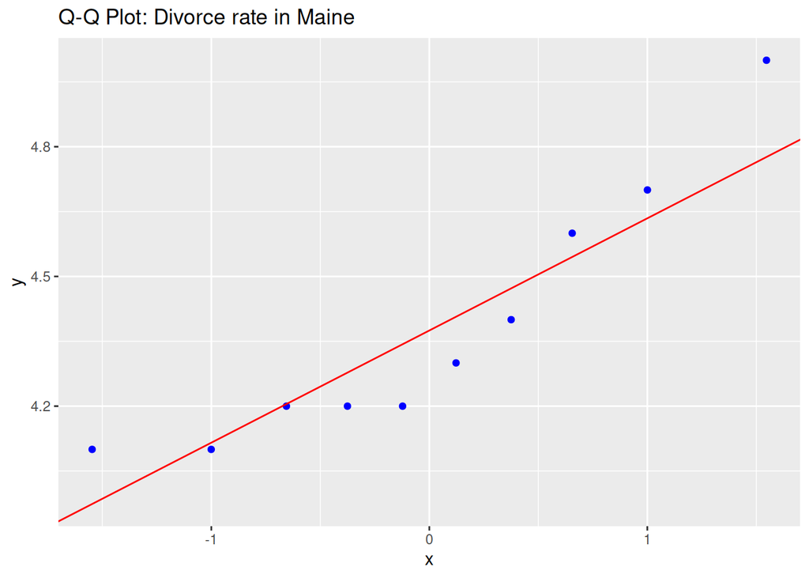

```r
ggplot(df_divorce_marg, aes(sample = divorce_rate_maine)) + #For qq-plots we specify a 'sample' instead of an x or y axis
  stat_qq(color = "blue") + # Colours
  stat_qq_line(color = "red") +
  labs(title = "Q-Q Plot: Divorce rate in Maine")
```

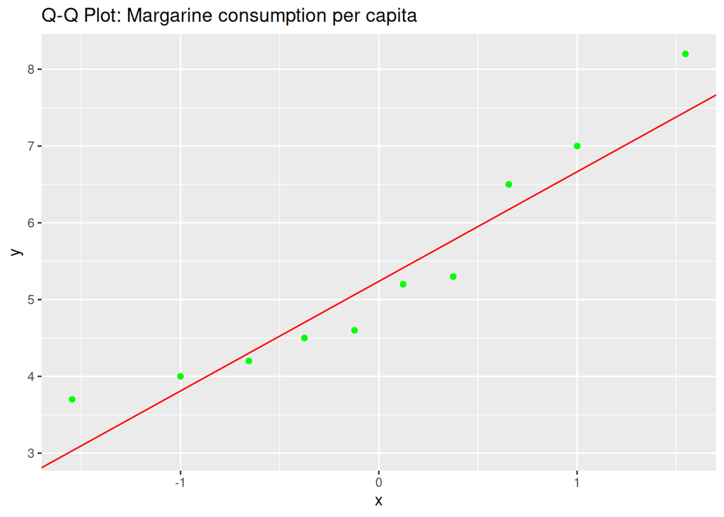

```r
ggplot(df_divorce_marg, aes(sample = margarine_consumption_per_capita)) + #For qq-plots we specify a 'sample' instead of an x or y axis
  stat_qq(color = "green") + # Colours
  stat_qq_line(color = "red") +
  labs(title = "Q-Q Plot: Margarine consumption per capita")
```

Both variables deviate from the reference line somewhat; It is probably not normally distributed.

### Shapiro-wilk test

```r
shapiro.test(df_divorce_marg$divorce_rate_maine)
```

```
##
##  Shapiro-Wilk normality test
##
## data:  df_divorce_marg$divorce_rate_maine
## W = 0.86135, p-value = 0.07916
```

```r
shapiro.test(df_divorce_marg$margarine_consumption_per_capita)
```

```
##
##  Shapiro-Wilk normality test
##
## data:  df_divorce_marg$margarine_consumption_per_capita
## W = 0.90531, p-value = 0.2503
```

“How to interpret the results: Look at the p-value: - p > 0.05 → Fail to reject H₀ → Data can be treated as approximately normal. - p ≤ 0.05 → Reject H₀ → Consider non-parametric methods or transformations.

W statistic: - W ranges from 0 to 1. - Values closer to 1 indicate data closer to normal.”

Both p-values are above 0.05 so the data is probably normal. Both W values are close to 1, also a sign of normality. This is surprising since the plots didn’t look normally distributed.

### Correlation test

```r
# I've decided to use the Pearson correlation test, assuming the data is normal

cor.test(df_divorce_marg$divorce_rate_maine, df_divorce_marg$margarine_consumption_per_capita, method = "pearson")
```

```
##
##  Pearson's product-moment correlation
##
## data:  df_divorce_marg$divorce_rate_maine and df_divorce_marg$margarine_consumption_per_capita
## t = 23.055, df = 8, p-value = 1.33e-08
## alternative hypothesis: true correlation is not equal to 0
## 95 percent confidence interval:
##  0.9676666 0.9983038
## sample estimates:
##       cor
## 0.9925585
```

### Part 1 Report

A Pearson correlation coefficient was computed to assess the linear relationship between the divorce rate in Maine and per capita margarine consumption. There was a strong positive correlation between the two variables, r (8) = .99, p < .05

However, this doesn’t make sense since the values obviously aren’t related in real life. The correlation doesn’t tell us anything about causation.

# Part 2

Work with the ‘GSSvocab’ dataset from the ‘car’ package, focusing only on the year 1978 (subset that year and exclude missing values). Investigate how vocabulary test scores (vocab) are related to education (educ). Present the relationship in a plot, fit a regression model, and report results in APA format (coefficients, p-values, and R2), followed by a short practical interpretation.

Extend the analysis by making a new model, where you include whether a person is native-born (nativeBorn) as a predictor. Again, visualise and model the relationship. Consider whether education and native-born status interact in predicting vocabulary, and if so, fit an interaction model. For each model, report results in APA format and explain the practical meaning.

Finally, compare the models and discuss which one performs best based on p-values and R2, as well as the real-world interpretability of the result

## Loading data frame

```r
#  loading the original data frame
df_vocab_base <- as.data.frame(GSSvocab)

#  subset to only year 1978
df_vocab <- df_vocab_base %>% filter(year == 1978)

#  removing NAs
df_vocab <- df_vocab %>% drop_na()

head(df_vocab)
```

```
##        year gender nativeBorn ageGroup educGroup vocab age educ
## 1978.1 1978 female        yes    50-59    12 yrs    10  52   12
## 1978.2 1978 female        yes      60+   <12 yrs     6  74    9
## 1978.3 1978   male        yes    30-39   <12 yrs     4  35   10
## 1978.4 1978 female        yes    50-59    12 yrs     9  50   12
## 1978.5 1978 female        yes    40-49    12 yrs     6  41   12
## 1978.6 1978   male        yes    18-29    12 yrs     6  19   12
```

### Exploring relationship between vocabulary test scores and education

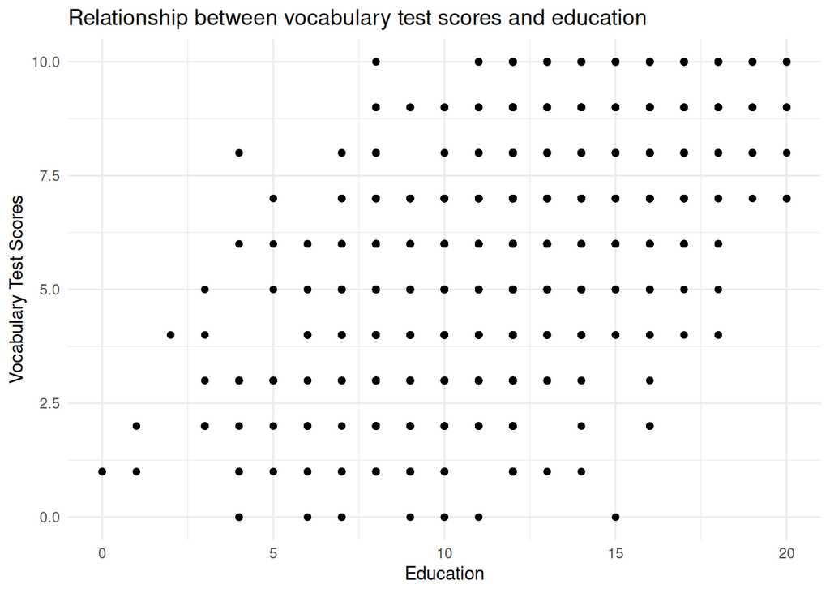

```r
ggplot(df_vocab, aes(x = educ, y = vocab)) +
  geom_point() +
  theme_minimal() +
  labs(title = "Relationship between vocabulary test scores and education", x = "Education", y = "Vocabulary Test Scores")
```

It looks like the vocab scores rise with a person’s level of education. This will be investigated further…

## Regression model 1: vocab, educ

```r
model_vocab <- lm(vocab ~ educ, data = df_vocab)
summary(model_vocab)
```

```
##
## Call:
## lm(formula = vocab ~ educ, data = df_vocab)
##
## Residuals:
##     Min      1Q  Median      3Q     Max
## -7.1233 -1.1608  0.0542  1.0917  5.6243
##
## Coefficients:
##             Estimate Std. Error t value Pr(>|t|)
## (Intercept)  1.23567    0.19957   6.192  7.7e-10 ***
## educ         0.39251    0.01606  24.443  < 2e-16 ***
## ---
## Signif. codes:  0 '***' 0.001 '**' 0.01 '*' 0.05 '.' 0.1 ' ' 1
##
## Residual standard error: 1.885 on 1475 degrees of freedom
## Multiple R-squared:  0.2883, Adjusted R-squared:  0.2878
## F-statistic: 597.5 on 1 and 1475 DF,  p-value: < 2.2e-16
```

### Results and Interpretation

Education predicted vocabulary test scores, R2 = .29, F(1, 1475) = 597.5, p < .05

The results tell us that the education can significantly predict the vocab test scores. This makes sense since you’ll generally do better in tests if you’re better educated or more well-read.

## Regression model 2: vocab, educ, native-born

```r
model_vocab_native <- lm(vocab ~ educ + nativeBorn, data = df_vocab)
summary(model_vocab_native)
```

```
##
## Call:
## lm(formula = vocab ~ educ + nativeBorn, data = df_vocab)
##
## Residuals:
##    Min     1Q Median     3Q    Max
## -7.162 -1.200  0.015  1.231  5.803
##
## Coefficients:
##               Estimate Std. Error t value Pr(>|t|)
## (Intercept)    0.62803    0.27651   2.271  0.02327 *
## educ           0.39222    0.01601  24.499  < 2e-16 ***
## nativeBornyes  0.65032    0.20551   3.164  0.00159 **
## ---
## Signif. codes:  0 '***' 0.001 '**' 0.01 '*' 0.05 '.' 0.1 ' ' 1
##
## Residual standard error: 1.879 on 1474 degrees of freedom
## Multiple R-squared:  0.2931, Adjusted R-squared:  0.2921
## F-statistic: 305.6 on 2 and 1474 DF,  p-value: < 2.2e-16
```

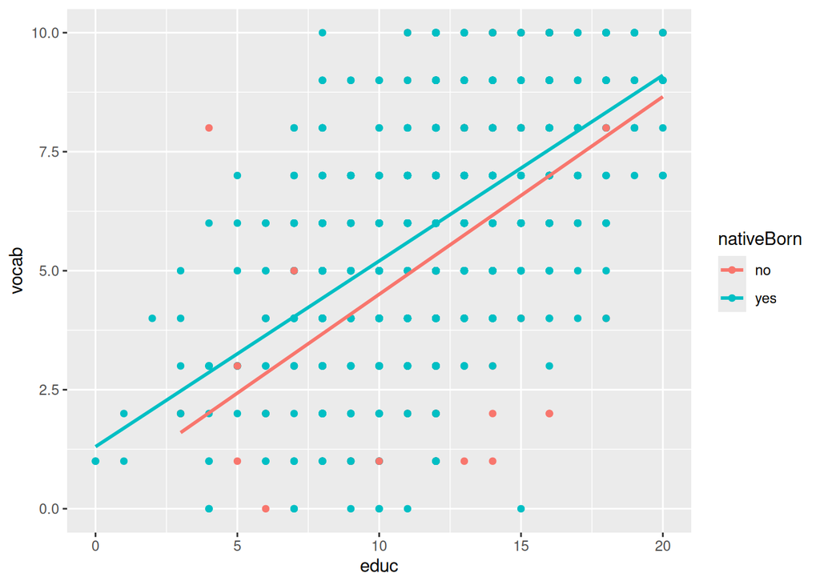

```r
ggplot(model_vocab_native, aes(x = educ, y = vocab, color = nativeBorn)) +
  geom_point() +
  geom_smooth(method = "lm", se = FALSE)
```

### Results

Native-born status significantly predicted vocabulary test scores, R2 = .29, F(2, 1474) = 305.60, p < .05

This would mean that native-born people generally have higher vocab test scores.

## Regression model 3: vocab, educ, native-born with interaction

```r
model_vocab_native_2 <- lm(vocab ~ educ * nativeBorn, data = df_vocab)
summary(model_vocab_native_2)
```

```
##
## Call:
## lm(formula = vocab ~ educ * nativeBorn, data = df_vocab)
##
## Residuals:
##     Min      1Q  Median      3Q     Max
## -7.1554 -1.2049  0.0149  1.2347  5.9857
##
## Coefficients:
##                    Estimate Std. Error t value Pr(>|t|)
## (Intercept)         0.35394    0.68780   0.515    0.607
## educ                0.41510    0.05496   7.553 7.45e-14 ***
## nativeBornyes       0.95000    0.71855   1.322    0.186
## educ:nativeBornyes -0.02501    0.05745  -0.435    0.663
## ---
## Signif. codes:  0 '***' 0.001 '**' 0.01 '*' 0.05 '.' 0.1 ' ' 1
##
## Residual standard error: 1.88 on 1473 degrees of freedom
## Multiple R-squared:  0.2932, Adjusted R-squared:  0.2917
## F-statistic: 203.7 on 3 and 1473 DF,  p-value: < 2.2e-16
```

### Results

The education * native-born interaction was not significant, R2 = .29, F(3, 1473), p = .663 (overall model: p < .05)

This means that there’s no evidence that native-born status has an effect on the relationship between education and vocab scores.

## Final results and model comparison

Education seems to strongly predict vocab test scores. Native-born people also seem to do better in vocab tests, probably because they’re fluent in the language vocabulary being tested.